# R Task Rabbit

First, read the data from .csv file.

```r
rabbit_data <- read.table("sample.csv", header = TRUE, sep = ",")
head(rabbit_data)
```

|  | recommendation_id | created_at | tasker_id | position | hourly_rate | num_completed_tasks | hired | category |
| --- | --- | --- | --- | --- | --- | --- | --- | --- |
| 1 | 0-0-70cf97d7-37af-4834-901c-ce3ad4893b8c | 2017-09-01 00:32:25 | 1009185352 | 1 | 38 | 151 | 0 | Furniture Assembly |
| 2 | 0-0-70cf97d7-37af-4834-901c-ce3ad4893b8c | 2017-09-01 00:32:25 | 1006892359 | 2 | 40 | 193 | 0 | Furniture Assembly |
| 3 | 0-0-70cf97d7-37af-4834-901c-ce3ad4893b8c | 2017-09-01 00:32:25 | 1012023956 | 3 | 28 | 0 | 0 | Furniture Assembly |
| 4 | 0-0-70cf97d7-37af-4834-901c-ce3ad4893b8c | 2017-09-01 00:32:25 | 1009733517 | 4 | 43 | 303 | 0 | Furniture Assembly |
| 5 | 0-0-70cf97d7-37af-4834-901c-ce3ad4893b8c | 2017-09-01 00:32:25 | 1013579273 | 5 | 29 | 39 | 0 | Furniture Assembly |
| 6 | 0-0-70cf97d7-37af-4834-901c-ce3ad4893b8c | 2017-09-01 00:32:25 | 1012043028 | 6 | 28 | 2 | 0 | Furniture Assembly |

Following are questions and answers about the data in the CSV sample file:

1. How many recommendation sets are in this data sample?

```r
length(unique(rabbit_data$recommendation_id))
```

```
[1] 2100
```

Answer : Total no of recommendation sets are 2100 in this data set.

2. Each recommendation set shows from 1 to 15 Taskers, what is:
- average number of Taskers shown

```r
rabbit_data$position <- as.factor(rabbit_data$tasker_id)
total_no_shown <- as.numeric(length(rabbit_data$recommendation_id))
tolal_tasker <- as.numeric(length(unique(rabbit_data$tasker_id)))
avg_no_tasker <- total_no_shown/tolal_tasker
avg_no_tasker
```

```
[1] 36.14458
```

```
  Answer : Average number of Taskers shown 36.14458
```

- median number of Taskers shown

```r
tasker_data <- table(rabbit_data$tasker_id)
nrow(tasker_data)
```

```
[1] 830
```

```r
sort(tasker_data)[416]
```

```
1009820249
        16
```

```
   Answer: - Median  number of Taskers shown is 16
   count the frequency of the tasker appears as per recommendation set. Arrange the frequency and as the number of observations is 830 then the median number of Taskers shown would be at 416 th position that is 16.
```

3. How many total unique Taskers are there in this data sample?

```r
unique_tsker <- length(unique(rabbit_data$tasker_id))
unique_tsker
```

```
[1] 830
```

Answer: Total unique 830 Taskers are there in this data sample

4. Which Tasker has been shown the most?

```r
tail(names(sort(table(rabbit_data$tasker_id))), 1)
```

```
[1] "1014508755"
```

```r
length(rabbit_data$tasker_id[rabbit_data$tasker_id == "1014508755"])
```

```
[1] 608
```

```r
#sort(table(rabbit_data$tasker_id[rabbit_data$tasker_id == "1014508755"]))
```

Answer: Tasker with “1014508755” appear most with count 608.

Which Tasker has been shown the least?

```r
head(names(sort(table(rabbit_data$tasker_id))), 1)
```

```
[1] "1006690425"
```

```r
length(rabbit_data$tasker_id[rabbit_data$tasker_id == "1006690425"])
```

```
[1] 1
```

```r
#sort(table(rabbit_data$tasker_id[rabbit_data$tasker_id == "1006690425"]))
```

[output not shown]

5. Which Tasker has been hired the most?

```r
most_hired <- tail(names(sort(table(rabbit_data$tasker_id[rabbit_data$hired == 1]))), 1)
most_hired
```

```
[1] "1012043028"
```

```r
length(rabbit_data$tasker_id[rabbit_data$hired == 1 & rabbit_data$tasker_id == most_hired])
```

```
[1] 59
```

```
Answer: 1012043028 Tasker has been hired the most with count 59
```

Which Tasker has been hired the least?

```r
least_hired <- head(names(sort(table(rabbit_data$tasker_id[rabbit_data$hired == 1]))), 1)
least_hired
```

```
[1] "1006720321"
```

```r
length(rabbit_data$tasker_id[rabbit_data$hired == 1 & rabbit_data$tasker_id == least_hired])
```

```
[1] 1
```

Answer: 1006720321 Tasker has been hired the least with count 1

6. If we define the “Tasker conversion rate” as the number of times a Tasker has been hired, out of the number of times the Tasker has been shown, how many Taskers have a conversion rate of 100%

```r
get_lenght_hired <- function(id)
{
  get_length_hired <- length(rabbit_data$tasker_id[rabbit_data$hired == 1 & rabbit_data$tasker_id == id])
  if(get_length_hired)
  {
    return(get_length_hired)
  }
  else
  {
    return(0)
  }
}
get_lenght_shown<- function(id)
{
  get_lenght_shown <- length(rabbit_data$recommendation_id[rabbit_data$tasker_id == id])
  if(get_lenght_shown)
  {
    return(get_lenght_shown)
  }
  else
  {
    return(0)
  }
}
```

```r
unique_id <- unique(rabbit_data$tasker_id)
tasker_id <-NULL
appear_cnt <-NULL
hired_cnt <- NULL
for (i in 1:length(unique_id))
{
  tasker_id[i] <- unique_id[i]
  appear_cnt[i] <- get_lenght_shown(unique_id[i])
  hired_cnt[i] <- get_lenght_hired(unique_id[i])
}
task_conversion <- data.frame(id = tasker_id,AppearCount = appear_cnt ,HiredCount = hired_cnt)
length(task_conversion$id[task_conversion$AppearCount == task_conversion$HiredCount])
```

```
[1] 6
```

```r
task_conversion$id[task_conversion$AppearCount == task_conversion$HiredCount]
```

```
[1] 1011985968 1007480912 1008861741 1012369686 1008094420 1014478773
```

```
 Answer: There are 6 Taskers have a conversion rate of 100%
```

7. Would it be possible for all Taskers to have a conversion rate of 100% Please explain your reasoning.

Answer: Not possible practically, Only possible if tasker showed once and get hired. and takser only get one chance to get hired and show.

```r
table(rabbit_data$category[rabbit_data$hired == 1])
```

```
Furniture Assembly           Mounting        Moving Help
               572                562                571
```

9. For each category, what is the average hourly rate and average number of completed tasks for the Taskers who are hired?

```r
aggregate(cbind(num_completed_tasks,hourly_rate) ~ category, rabbit_data, mean)
```

| category | num_completed_tasks | hourly_rate |
| --- | --- | --- |
| Furniture Assembly | 185.8338 | 39.4197 |
| Mounting | 220.2708 | 50.4749 |
| Moving Help | 257.6025 | 82.5530 |

[output not shown]

10. Based on the previous, how would you approach the question of:

    How can we use market data to suggest hourly rates to Taskers that would maximize their opportunity to be hired?

    Please describe in detail, with code and formulas that support your model.

```r
data_hired <-  subset(rabbit_data, rabbit_data$hired == 1)
data_hired$position <- as.factor(data_hired$position)
str(data_hired)
```

```
'data.frame':   1705 obs. of  8 variables:
 $ recommendation_id  : Factor w/ 2100 levels "0-0-00033225-3f89-47dd-b4f1-5d1feb359a76",..: 1322 1954 1169 146 2029 270 294 1881 396 353 ...
 $ created_at         : Factor w/ 2093 levels "2017-09-01 00:32:25",..: 1 2 3 4 7 8 9 10 11 12 ...
 $ tasker_id          : int  1009856900 1009856900 1011985968 1009114267 1009072269 1009072269 1007081910 1007081910 1007081910 1008147271 ...
 $ position           : Factor w/ 15 levels "1","2","3","4",..: 13 10 3 4 11 9 2 2 2 2 ...
 $ hourly_rate        : int  50 50 32 95 35 35 42 42 42 34 ...
 $ num_completed_tasks: int  914 914 0 1053 59 59 353 353 353 75 ...
 $ hired              : int  1 1 1 1 1 1 1 1 1 1 ...
 $ category           : Factor w/ 3 levels "Furniture Assembly",..: 1 1 3 3 1 1 1 1 1 3 ...
```

Step 2: Check Missing value using missmap function

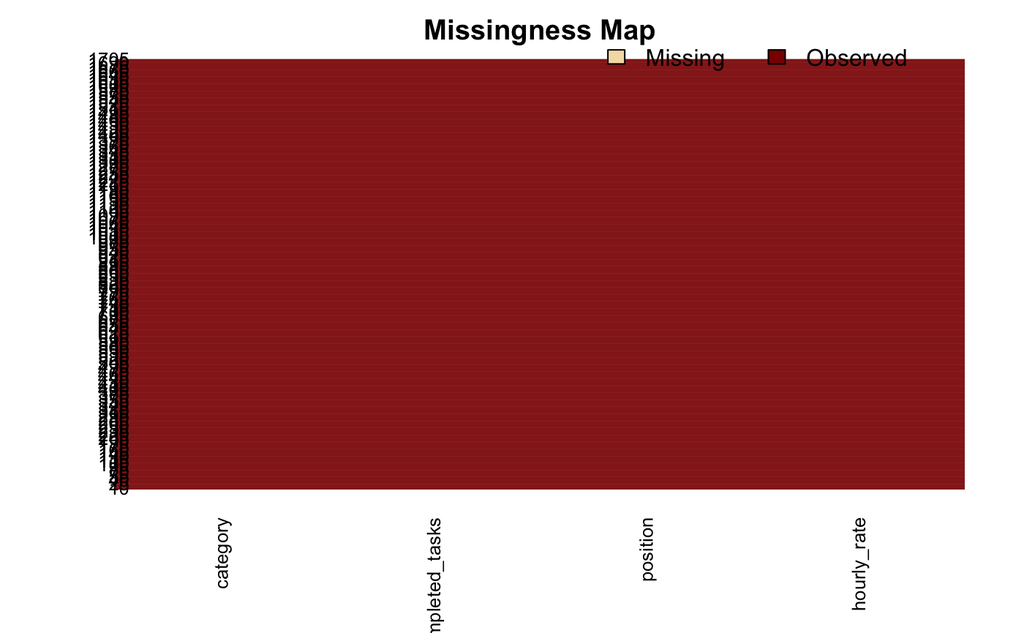

```r
data_hired <- subset(data_hired,select = c("hourly_rate","position","num_completed_tasks","category"))
library(Amelia)
missmap(data_hired)
```

Step 3: Find the correlation between dependent and independent variable by visualizing data

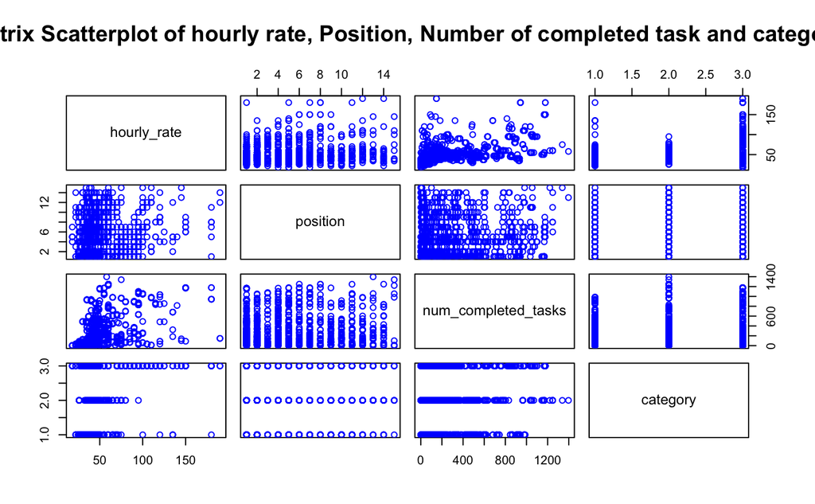

```r
plot(data_hired, col="blue", main="Matrix Scatterplot of hourly rate, Position, Number of completed task and category")
```

[figure not shown]

```r
plot(data_hired$hourly_rate ~ data_hired$position, col="blue", main="Scatterplot of hourly rate and Number of completed task")
```

[figure not shown]

```r
plot(data_hired$hourly_rate ~ data_hired$num_completed_tasks, col="blue", main="Bar char to display relation between the Hourly rate and Position")
```

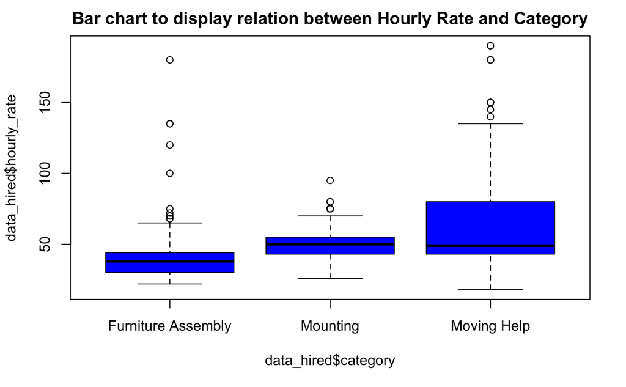

```r
plot(data_hired$hourly_rate ~ data_hired$category, col="blue", main="Bar chart to display relation between Hourly Rate and Category")
```

Form above second graphs we can not conculed the conclued the postion have a positive influence on the hourly rate. In the third graph can see the positive increment in hourly rate as per the frequency of task submissions. and finally category plays a positive influence on hourly rate.

Step 4: Create sample data set to bult the model

```r
set.seed(100)
data_rows_sample <- sample(1:nrow(data_hired),round(0.7*nrow(data_hired)))
data_hired_sample <- data_hired[data_rows_sample,]
data_hired_test <- data_hired[-data_rows_sample,]
```

Step 5: Build linear regression model to predict the hourly rate from the position, category, and a number of completed task.

```r
model <- lm(hourly_rate~category+position+num_completed_tasks,data_hired_sample)
summary(model)
```

```
Call:
lm(formula = hourly_rate ~ category + position + num_completed_tasks,
    data = data_hired_sample)

Residuals:
    Min      1Q  Median      3Q     Max
-51.296 -10.341  -0.495   6.511 128.185

Coefficients:
                     Estimate Std. Error t value Pr(>|t|)
(Intercept)         27.552991   1.097778  25.099  < 2e-16 ***
categoryMounting    10.596508   1.212386   8.740  < 2e-16 ***
categoryMoving Help 22.919228   1.213564  18.886  < 2e-16 ***
position2            1.651625   1.497640   1.103 0.270332
position3           12.372231   2.586835   4.783 1.95e-06 ***
position4            0.802252   1.697114   0.473 0.636504
position5            2.265486   2.079467   1.089 0.276176
position6            5.711062   2.543759   2.245 0.024945 *
position7            9.125585   2.361604   3.864 0.000118 ***
position8           15.526949   3.029250   5.126 3.46e-07 ***
position9            6.892842   2.983051   2.311 0.021024 *
position10           7.070930   2.733395   2.587 0.009804 **
position11           6.807191   3.170070   2.147 0.031971 *
position12          13.124561   3.265362   4.019 6.21e-05 ***
position13           7.775567   3.601056   2.159 0.031033 *
position14           6.694506   3.595881   1.862 0.062893 .
position15          -3.462736   8.442998  -0.410 0.681784
num_completed_tasks  0.031410   0.001711  18.354  < 2e-16 ***
---
Signif. codes:  0 ‘***’ 0.001 ‘**’ 0.01 ‘*’ 0.05 ‘.’ 0.1 ‘ ’ 1

Residual standard error: 16.73 on 1176 degrees of freedom
Multiple R-squared:  0.4364,    Adjusted R-squared:  0.4282
F-statistic: 53.56 on 17 and 1176 DF,  p-value: < 2.2e-16
```

Step 6: Analysis

Example:

Visulise and Apply above model on test data

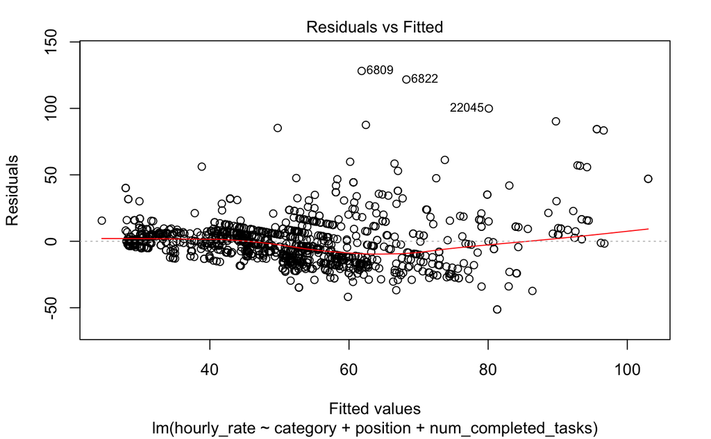

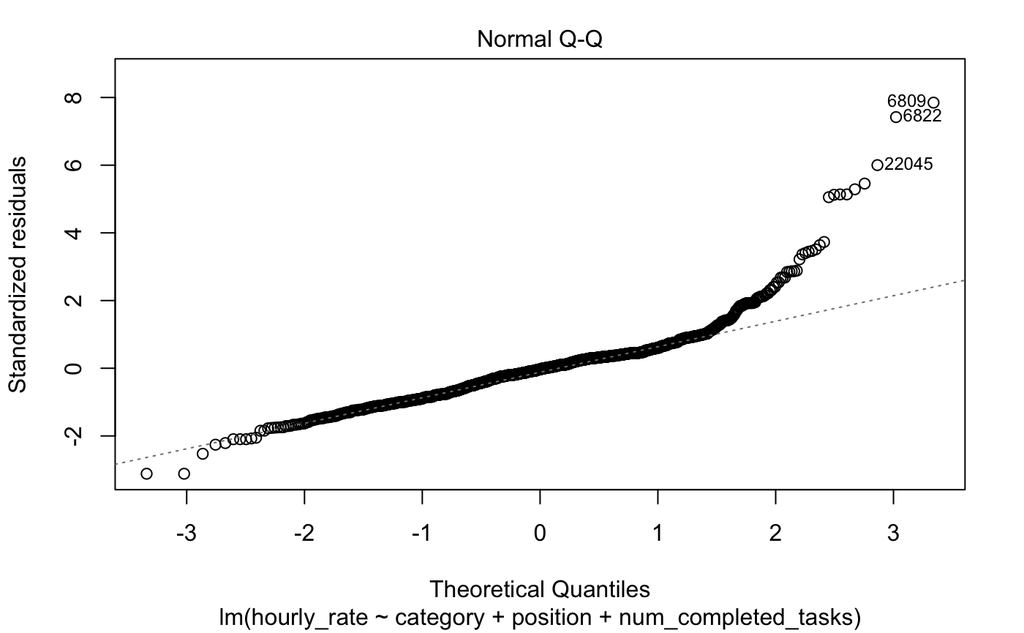

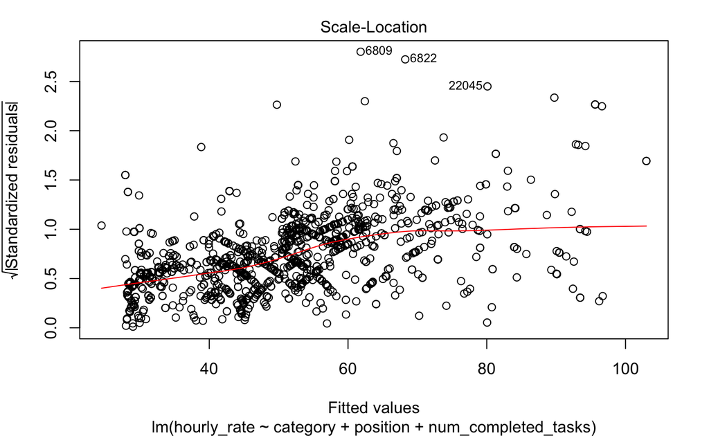

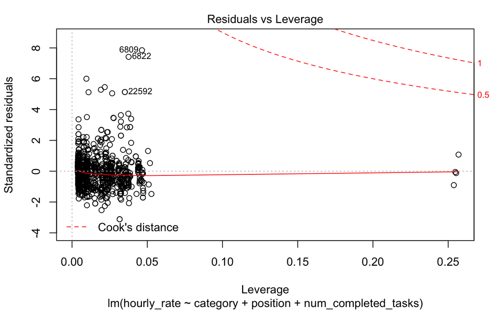

```r
plot(model)
```

```r
suggest_hourly_rates <- predict.lm(model,data_hired_test)
#class(data_hired_test)
```

The above liner regression model we can use for suggest hourly rates to Taskers that would maximize their opportunity to be hired.